[figure not shown]

CS F364: Design & Analysis of Algorithms

# Edmonds-Karp Algorithm & Bipartite Matching

Lecture 25 |2026-06-14

Tulasimohan Molli BITS Pilani, Hyderabad Campus

# Network Flow

- Network Flow
- The Edmonds-Karp Algorithm
- Algorithm & Complexity
- Conclusion

# The Edmonds-Karp Algorithm

- Network Flow
- The Edmonds-Karp Algorithm
- Algorithm & Complexity
- Conclusion

The Edmonds-Karp Insight **What makes Edmonds-Karp different?**

- Published by Jack Edmonds and Richard Karp in 1972 (independently discovered by Yefim Dinitz in 1970).
- It specifies exactly *how* to find the augmenting path.
- **The Rule:** Always choose the augmenting path with the **fewest number of edges**.
- **How:** Find the path using **Breadth-First Search (BFS)**.

Residual Networks To understand how we augment flow, we need the **residual network** $G_f$.

- The residual capacity $c_f(u, v)$ is the additional flow we can push from $u$ to $v$.
- **Forward edges:** $c_f(u, v) = c(u, v) - f(u, v)$.
- **Backward edges:** We can "undo" flow we already pushed. $c_f(v, u) = f(u, v)$.
- The BFS runs on $G_f$, looking for any path from $s$ to $t$ where every edge has $c_f > 0$.

# Algorithm & Complexity

- Network Flow
- The Edmonds-Karp Algorithm
- Algorithm & Complexity
- Conclusion

Time Complexity **Total Time Complexity:** $\mathcal{O}(V E^2)$

- **BFS Cost:** Finding a shortest path takes $\mathcal{O}(E)$ time.
- **Number of Augmentations:** The key theorem of Edmonds-Karp states that the total number of flow augmentations is bounded by $\mathcal{O}(VE)$.
- **Why?** The shortest path distance from the source to any node in the residual graph increases monotonically. Each edge can become a "bottleneck" at most $V/2$ times.
- $\mathcal{O}(E)$ per BFS $\times$ $\mathcal{O}(VE)$ augmentations = $\mathcal{O}(V E^2)$.

# Conclusion

- Network Flow
- The Edmonds-Karp Algorithm
- Algorithm & Complexity
- Conclusion

Summary

- Edmonds-Karp is a robust, fully polynomial-time implementation of the Ford-Fulkerson method.
- By using BFS to find the shortest augmenting path (in terms of edge count), it avoids the pathological worst-cases of generic Ford-Fulkerson.
- It is guaranteed to terminate and find the maximum flow, even for networks with irrational capacities.
- It runs in $\mathcal{O}(V E^2)$ time, making it practical for many real-world network flow problems.

## Bipartite Matching

- Suppose we have two sets: $L$ (set of people) and $R$ (set of jobs)
- A person can do more than one jobs.
- We can model this as a bipartite graph as shown in the figure

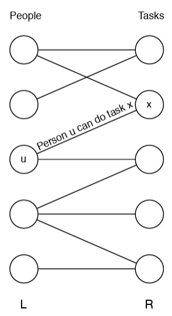

## Bipartite Matching

- A matching gives an assignment of people to tasks such that a person can do at most one task and no two person can do a task together.
- Formally, a matching is a subset of edges $M\subseteq E$ such that for all vertices $v\in V$, at most one edge of $M$ is incident on $v$.

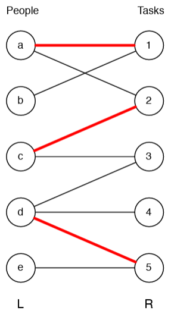

## Maximum Bipartite Matching

Given a bipartite graph $G = (L, R, E)$, find a matching $M\subseteq E$ such that $|M|$ is the largest.

Observations:

- $M$ is a perfect matching if every vertex is matched.
- Maximum is not same as maximal: greedy will get to maximal one.

## Reduction

- Given: an instance of bipartite matching.
- Generate: an instance of network flow.
- Solution to the maximum flow problem can be used to find maximum bipartite matching.

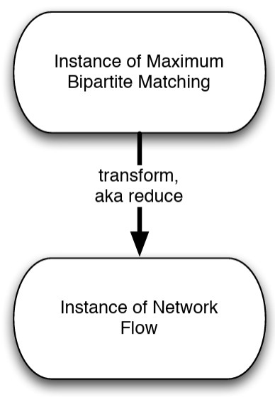

## Reduction

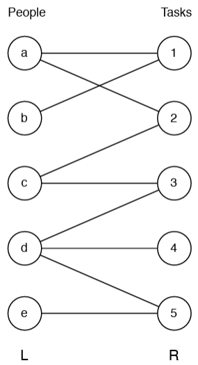

## Reduction

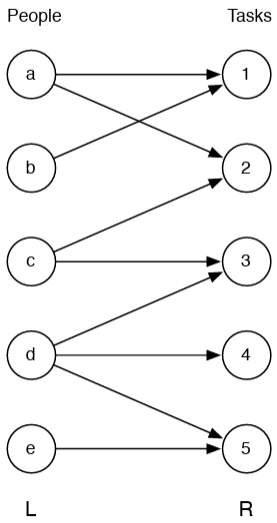

## Reduction

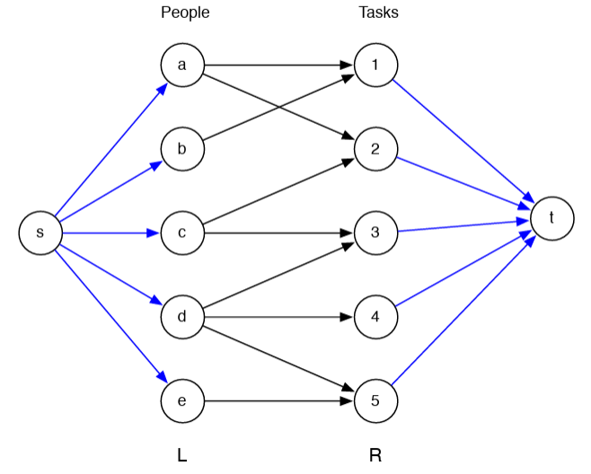

## Reduction

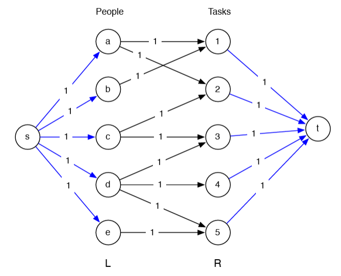

## Network Flow to Bipartite Matching

- Given a bipartite graph $G = (L, R, E)$, direct the edges from $L$ to $R$.
- Add new vertices $s$ and $t$.
- Add an edge from $s$ to every vertex in $L$.
- Add an edge from every vertex in $R$ to $t$.
- Make all the capacities $1$. This completes the construction of $G'$.
- Solve maximum flow problem on the new flow network $G'$.

**Edges used in the maximum flow corresponds to the maximum matching.**

## Network Flow to Bipartite Matching

- Suppose $M$ is the maximum flow in $G'$.
- Because, capacities are integral, max flow will be integral.
- Because the capacities are all $1$’s:
  - Either use an edge completely (sending $1$ unit of flow)
  - or do not use the edge at all.

We will show:

- $M$ is a matching.
- $M$ is maximum.

## $M$ is a matching

- We can choose at most one edge leaving any node in $L$.
- We can choose at most one edge entering any node in $R$.

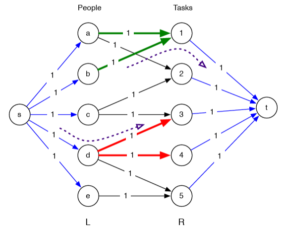

## $M$ is maximum

- Suppose we find a maximum flow $f^* = k$.
- This corresponds to a matching $M$ of size $k$.
- Suppose $M$ is not maximum, and there is another matching $M'$ of size greater than $k$.
- Then $f^*$ is not maximum. This is a contradiction.
- Thus $M$ is maximum.

## Time Complexity

- Maximum value of the flow is $n$ where $|L|=n$.
- The number of edges in $G'$ is $m + 2n$ where $m$ is the number of edges in $G$.
- Using Ford-Fulkerson algorithm, the time complexity is $O(mn)$.